# anomaly-detection

### Jupyter Notebook: Anomaly Detection with Shallow and Deep Learning Methods

#### This notebook is for demonstration ONLY.

> "More effort, you must put, to make it work." — **Master Yoda**

This notebook explores various approaches to anomaly detection using both traditional machine learning (shallow) and deep learning methods. The objective is to provide an educational demonstration of how different algorithms can be applied to detect anomalies in data. Please note that this notebook is intended solely for educational purposes and does not aim to achieve high performance or benchmark-level results.

You will be guided through several stages of the anomaly detection pipeline, with a focus on data handling, model selection, and implementation. We leverage libraries such as Pandas, Scikit-learn, and PyTorch to illustrate the differences between classic and Deep Learning approaches.

The notebook is organized into the following sections:

We will focuns on aspects about

1. **Dataset Preparation:**
- Load the dataset suitable for anomaly detection tasks.
- Explore data structure and key characteristics.
- Preprocessing Techniques: using Pandas and Sklearn
- Handle missing values, duplicates.
- Normalize data using techniques like StandardScaler or MinMaxScaler.
- Learn how to use dimensionality reduction for visualization (e.g., PCA, T-SNE)
2. **Shallow Learning Methods: using Scikit-learn implementing and comparing**
- One-Class SVM
- Local Outlier Factor (LOF)
- k-means
- DB-Scan
- Evaluate the models with metrics suitable for unsupervised/supervised settings (e.g., SSE, Silhouette, and Classification reports).
  - ***NOTICE***: Despide we will use the label for performance evaluation we will not use it for training
3. **Deep Learning Methods: using PyTorch**
- Implement a simple Autoencoder for anomaly detection.
- Implement a more complex Autoencoder for anomaly detection.
- Train the model and monitor reconstruction loss.
- Identify anomalies based on reconstruction error thresholds.
- Visualization & Analysis

```python
!pwd
```

```
/share/smartdata/lake/ai_and_cybersecurity/anomaly_detection
```

```python
import pandas as pd
import numpy as np
import matplotlib.pyplot as plt
import matplotlib.cm as cm

import seaborn as sns
from sklearn.preprocessing import StandardScaler

from sklearn.neighbors import LocalOutlierFactor
from sklearn.cluster import KMeans, DBSCAN
from sklearn.svm import OneClassSVM

from sklearn.decomposition import PCA
from sklearn.manifold import TSNE

from sklearn.metrics import silhouette_score, silhouette_samples, pairwise_distances_argmin_min
from sklearn.metrics import classification_report, confusion_matrix
from sklearn.model_selection import train_test_split

from sklearn.preprocessing import OneHotEncoder, StandardScaler
from sklearn.neighbors import NearestNeighbors
from sklearn.compose import ColumnTransformer
```

### 📋 KDD Cup 1999 Feature Description

The KDD Cup 1999 dataset is a benchmark dataset used for evaluating network intrusion detection systems (IDS). It was built from raw TCP dump data collected during a simulated U.S. Air Force network environment. Each record in the dataset represents a connection between two network hosts and is labeled as either normal or as a specific type of attack.

| # | Feature Name | Type | Description |
| --- | --- | --- | --- |
| 1 | duration | Numeric | Length (in seconds) of the connection |
| 2 | protocol_type | Categorical | Protocol used (e.g., tcp, udp, icmp) |
| 3 | service | Categorical | Network service on the destination (e.g., http, telnet) |
| 4 | flag | Categorical | Status flag of the connection |
| 5 | src_bytes | Numeric | Bytes sent from source to destination |
| 6 | dst_bytes | Numeric | Bytes sent from destination to source |
| 7 | land | Binary | 1 if connection is from/to the same host/port, else 0 |
| 8 | wrong_fragment | Numeric | Number of wrong fragments |
| 9 | urgent | Numeric | Number of urgent packets |
| 10 | hot | Numeric | Number of "hot" indicators |
| 11 | num_failed_logins | Numeric | Number of failed login attempts |
| 12 | logged_in | Binary | 1 if successfully logged in; else 0 |
| 13 | num_compromised | Numeric | Number of compromised conditions |
| 14 | root_shell | Binary | 1 if root shell is obtained; else 0 |
| 15 | su_attempted | Binary | 1 if "su root" command attempted; else 0 |
| 16 | num_root | Numeric | Number of root accesses |
| 17 | num_file_creations | Numeric | Number of file creation operations |
| 18 | num_shells | Numeric | Number of shell prompts invoked |
| 19 | num_access_files | Numeric | Number of accesses to sensitive files |
| 20 | num_outbound_cmds | Numeric | Number of outbound commands in an ftp session |
| 21 | is_host_login | Binary | 1 if login belongs to host list; else 0 |
| 22 | is_guest_login | Binary | 1 if login is a guest; else 0 |
| 23 | count | Numeric | Number of connections to the same host in the past 2 seconds |
| 24 | srv_count | Numeric | Number of connections to the same service in the past 2 seconds |
| 25 | serror_rate | Numeric | % of connections that have SYN errors |
| 26 | srv_serror_rate | Numeric | % of connections to the same service with SYN errors |
| 27 | rerror_rate | Numeric | % of connections that have REJ errors |
| 28 | srv_rerror_rate | Numeric | % of REJ errors for the same service |
| 29 | same_srv_rate | Numeric | % of connections to the same service |
| 30 | diff_srv_rate | Numeric | % of connections to different services |
| 31 | srv_diff_host_rate | Numeric | % of connections to different hosts for the same service |
| 32 | dst_host_count | Numeric | Number of connections to same host |
| 33 | dst_host_srv_count | Numeric | Number of connections to same service |
| 34 | dst_host_same_srv_rate | Numeric | % of connections to same service |
| 35 | dst_host_diff_srv_rate | Numeric | % of connections to different services |
| 36 | dst_host_same_src_port_rate | Numeric | % of connections with same source port |
| 37 | dst_host_srv_diff_host_rate | Numeric | % of connections to same service on different hosts |
| 38 | dst_host_serror_rate | Numeric | % of connections to host with SYN errors |
| 39 | dst_host_srv_serror_rate | Numeric | % of connections to service with SYN errors |
| 40 | dst_host_rerror_rate | Numeric | % of connections to host with REJ errors |
| 41 | dst_host_srv_rerror_rate | Numeric | % of connections to service with REJ errors |
|  | **label** | Categorical | Type of connection: `normal` or specific attack type |

## 1. Load the dataset

```python
df = pd.read_csv("kddcup99_csv.csv")

# Display basic info
print("Initial shape:", df.shape)

# 2. Data Cleaning
# Drop duplicate rows
df.drop_duplicates(inplace=True)

# Display basic info
print("final shape:", df.shape)
```

```
Initial shape: (494020, 42)
final shape: (145585, 42)
```

### Investigate categorical variables

Learn their distribution and if we should keep all the values for each categorical feature

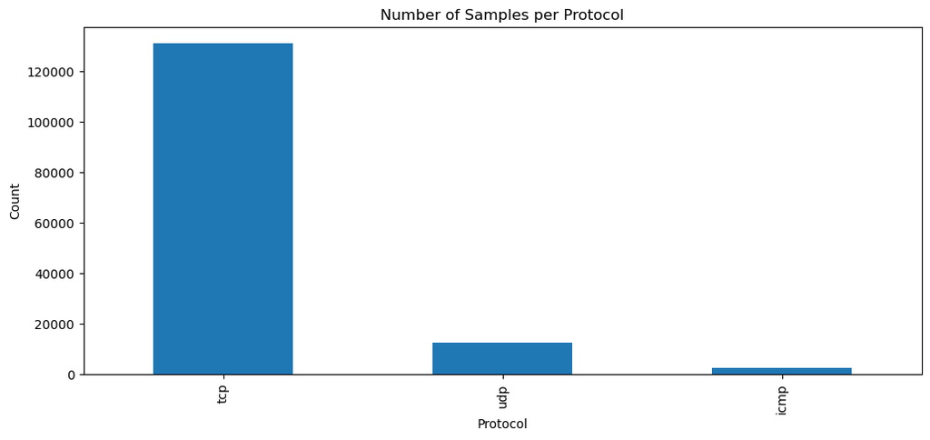

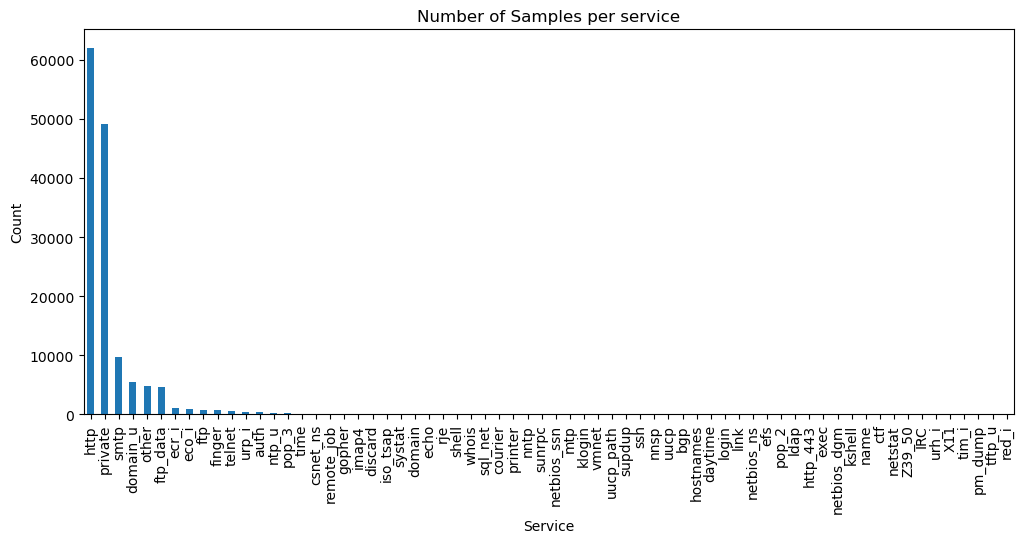

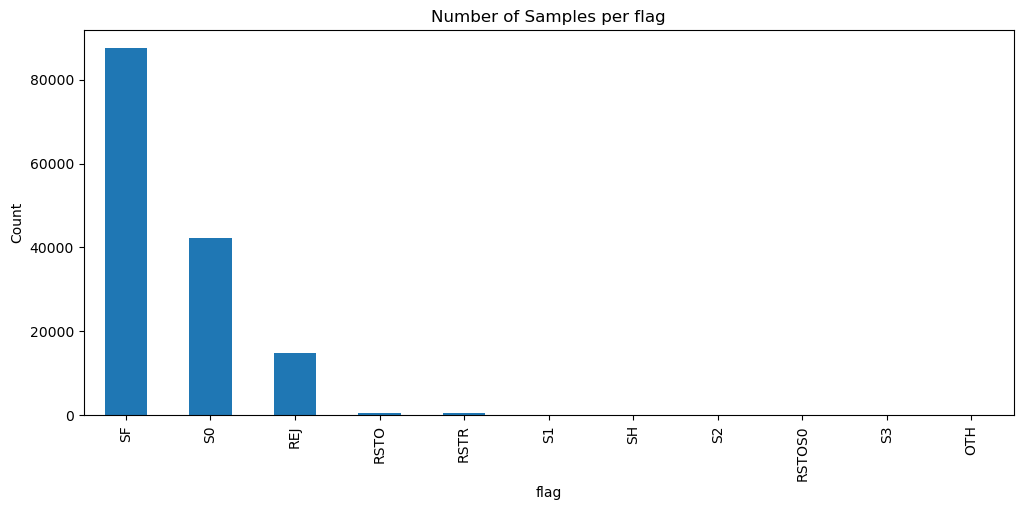

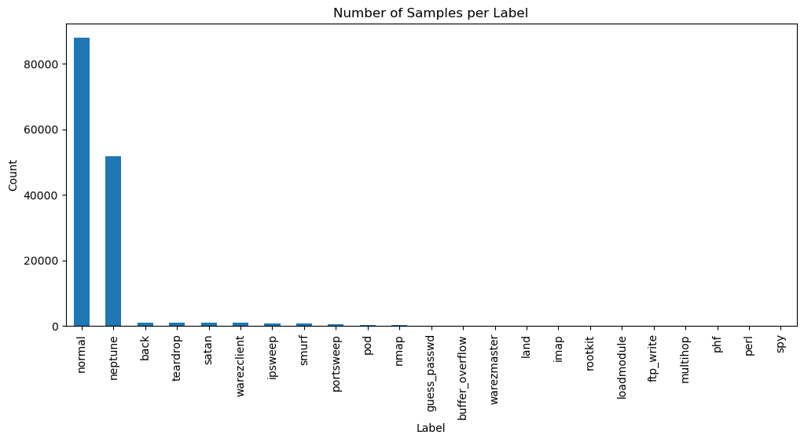

```python
df["protocol_type"].value_counts().plot(kind="bar", figsize=(12, 5))
plt.title("Number of Samples per Protocol")
plt.xlabel("Protocol")
plt.ylabel("Count")
plt.xticks(rotation=90)
plt.show()
plt.close()

df["service"].value_counts().plot(kind="bar", figsize=(12, 5))
plt.title("Number of Samples per service")
plt.xlabel("Service")
plt.ylabel("Count")
plt.xticks(rotation=90)
plt.show()
plt.close()

df["flag"].value_counts().plot(kind="bar", figsize=(12, 5))
plt.title("Number of Samples per flag")
plt.xlabel("flag")
plt.ylabel("Count")
plt.xticks(rotation=90)
plt.show()
plt.close()

df["label"].value_counts().plot(kind="bar", figsize=(12, 5))
plt.title("Number of Samples per Label")
plt.xlabel("Label")
plt.ylabel("Count")
plt.xticks(rotation=90)
plt.show()
plt.close()
```

```python
df["service"].value_counts()[:20]
```

```
http          62053
private       49057
smtp           9721
domain_u       5425
other          4769
ftp_data       4592
ecr_i          1027
eco_i           916
ftp             798
finger          668
telnet          512
urp_i           443
auth            328
ntp_u           290
pop_3           200
time            139
csnet_ns        126
remote_job      120
gopher          117
imap4           117
Name: service, dtype: int64
```

```python
df["flag"].value_counts()[:20]
```

```
SF        87458
S0        42278
REJ       14712
RSTO        569
RSTR        425
S1           57
SH           34
S2           24
RSTOS0       11
S3           10
OTH           7
Name: flag, dtype: int64
```

### Neptune Filter

**Note**: Since "neptune" is very frequnet, it can create very dense areas. These are not considered anomalies. We filter "neptune" out to see a case where anomalies are rare.

```python
df = df[df["label"] != "neptune"].copy()
```

```python
df
```

|  | duration | protocol_type | service | flag | src_bytes | dst_bytes | land | wrong_fragment | urgent | hot | ... | dst_host_srv_count | dst_host_same_srv_rate | dst_host_diff_srv_rate | dst_host_same_src_port_rate | dst_host_srv_diff_host_rate | dst_host_serror_rate | dst_host_srv_serror_rate | dst_host_rerror_rate | dst_host_srv_rerror_rate | label |
| --- | --- | --- | --- | --- | --- | --- | --- | --- | --- | --- | --- | --- | --- | --- | --- | --- | --- | --- | --- | --- | --- |
| 0 | 0 | tcp | http | SF | 181 | 5450 | 0 | 0 | 0 | 0 | ... | 9 | 1.0 | 0.0 | 0.11 | 0.00 | 0.00 | 0.00 | 0.0 | 0.0 | normal |
| 1 | 0 | tcp | http | SF | 239 | 486 | 0 | 0 | 0 | 0 | ... | 19 | 1.0 | 0.0 | 0.05 | 0.00 | 0.00 | 0.00 | 0.0 | 0.0 | normal |
| 2 | 0 | tcp | http | SF | 235 | 1337 | 0 | 0 | 0 | 0 | ... | 29 | 1.0 | 0.0 | 0.03 | 0.00 | 0.00 | 0.00 | 0.0 | 0.0 | normal |
| 3 | 0 | tcp | http | SF | 219 | 1337 | 0 | 0 | 0 | 0 | ... | 39 | 1.0 | 0.0 | 0.03 | 0.00 | 0.00 | 0.00 | 0.0 | 0.0 | normal |
| 4 | 0 | tcp | http | SF | 217 | 2032 | 0 | 0 | 0 | 0 | ... | 49 | 1.0 | 0.0 | 0.02 | 0.00 | 0.00 | 0.00 | 0.0 | 0.0 | normal |
| ... | ... | ... | ... | ... | ... | ... | ... | ... | ... | ... | ... | ... | ... | ... | ... | ... | ... | ... | ... | ... | ... |
| 494015 | 0 | tcp | http | SF | 310 | 1881 | 0 | 0 | 0 | 0 | ... | 255 | 1.0 | 0.0 | 0.01 | 0.05 | 0.00 | 0.01 | 0.0 | 0.0 | normal |
| 494016 | 0 | tcp | http | SF | 282 | 2286 | 0 | 0 | 0 | 0 | ... | 255 | 1.0 | 0.0 | 0.17 | 0.05 | 0.00 | 0.01 | 0.0 | 0.0 | normal |
| 494017 | 0 | tcp | http | SF | 203 | 1200 | 0 | 0 | 0 | 0 | ... | 255 | 1.0 | 0.0 | 0.06 | 0.05 | 0.06 | 0.01 | 0.0 | 0.0 | normal |
| 494018 | 0 | tcp | http | SF | 291 | 1200 | 0 | 0 | 0 | 0 | ... | 255 | 1.0 | 0.0 | 0.04 | 0.05 | 0.04 | 0.01 | 0.0 | 0.0 | normal |
| 494019 | 0 | tcp | http | SF | 219 | 1234 | 0 | 0 | 0 | 0 | ... | 255 | 1.0 | 0.0 | 0.17 | 0.05 | 0.00 | 0.01 | 0.0 | 0.0 | normal |

93765 rows × 42 columns

### Create a binary label normal vs. anomlay -- anything that is not normal is an anomaly!

```python
df["binary_label"] = df["label"].apply(lambda x: 0 if x =="normal" else 1)
```

### Downsample if needed for speeding up the process

```python
#df, _ = train_test_split(df, train_size=0.1, stratify=df["binary_label"],random_state=42)
```

### Split in Train, Validation and Test

Simulating a real scenario where we can ecode features only based on what we know (the training set)

```python
df_train_validation, df_test = train_test_split(df, train_size=0.9, stratify=df["binary_label"],random_state=42)
df_train, df_val = train_test_split(df_train_validation, train_size=0.9, stratify=df_train_validation["binary_label"],random_state=42)
```

### Reduce the number of possibile categories for each categorical feature

```python
# Define the allowed list of services
allowed_services = ["http", "private", "smtp", "domain_u", "other", "ftp_data", "ecr_i"]
# Apply the mapping WARNING we increase the diversity in in the "other" class
df_train["service"]   = df_train["service"].apply(lambda x: x if x in allowed_services else "other")
df_val["service"] = df_val["service"].apply(lambda x: x if x in allowed_services else "other")
df_test["service"]       = df_test["service"].apply(lambda x: x if x in allowed_services else "other")

# Define the allowed list of services
allowed_flag = ["SF", "S0", "REJ"]
# Apply the mapping
df_train["flag"]   = df_train["flag"].apply(lambda x: x if x in allowed_flag else "other")
df_val["flag"] = df_val["flag"].apply(lambda x: x if x in allowed_flag else "other")
df_test["flag"]       = df_test["flag"].apply(lambda x: x if x in allowed_flag else "other")
```

```python
df_train["flag"].value_counts()[:20]
```

```
SF       70789
REJ       4382
other      572
S0         206
Name: flag, dtype: int64
```

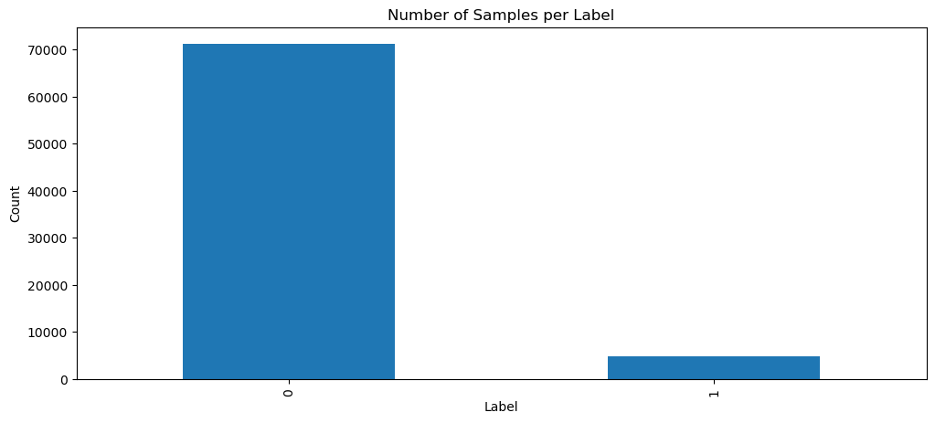

```python
df_train["binary_label"].value_counts().plot(kind="bar", figsize=(12, 5))
plt.title("Number of Samples per Label")
plt.xlabel("Label")
plt.ylabel("Count")
plt.xticks(rotation=90)
plt.show()
plt.close()
```

```python
df_train
```

|  | duration | protocol_type | service | flag | src_bytes | dst_bytes | land | wrong_fragment | urgent | hot | ... | dst_host_same_srv_rate | dst_host_diff_srv_rate | dst_host_same_src_port_rate | dst_host_srv_diff_host_rate | dst_host_serror_rate | dst_host_srv_serror_rate | dst_host_rerror_rate | dst_host_srv_rerror_rate | label | binary_label |
| --- | --- | --- | --- | --- | --- | --- | --- | --- | --- | --- | --- | --- | --- | --- | --- | --- | --- | --- | --- | --- | --- |
| 14018 | 0 | tcp | http | SF | 260 | 245 | 0 | 0 | 0 | 0 | ... | 1.00 | 0.00 | 0.00 | 0.02 | 0.00 | 0.0 | 0.0 | 0.0 | normal | 0 |
| 20675 | 0 | tcp | http | SF | 291 | 13599 | 0 | 0 | 0 | 0 | ... | 1.00 | 0.00 | 0.01 | 0.00 | 0.00 | 0.0 | 0.0 | 0.0 | normal | 0 |
| 140466 | 0 | tcp | other | SF | 1205 | 2447 | 0 | 0 | 0 | 28 | ... | 0.31 | 0.02 | 0.00 | 0.00 | 0.00 | 0.0 | 0.0 | 0.0 | warezclient | 1 |
| 13375 | 0 | tcp | http | SF | 221 | 1491 | 0 | 0 | 0 | 0 | ... | 1.00 | 0.00 | 0.00 | 0.00 | 0.00 | 0.0 | 0.0 | 0.0 | normal | 0 |
| 76126 | 0 | icmp | other | SF | 8 | 0 | 0 | 0 | 0 | 0 | ... | 1.00 | 0.00 | 1.00 | 0.27 | 0.00 | 0.0 | 0.0 | 0.0 | nmap | 1 |
| ... | ... | ... | ... | ... | ... | ... | ... | ... | ... | ... | ... | ... | ... | ... | ... | ... | ... | ... | ... | ... | ... |
| 7618 | 0 | tcp | smtp | SF | 1369 | 452 | 0 | 0 | 0 | 0 | ... | 0.81 | 0.02 | 0.01 | 0.01 | 0.11 | 0.0 | 0.0 | 0.0 | normal | 0 |
| 75199 | 22 | tcp | smtp | SF | 983 | 281 | 0 | 0 | 0 | 0 | ... | 0.54 | 0.04 | 0.01 | 0.01 | 0.00 | 0.0 | 0.0 | 0.0 | normal | 0 |
| 76492 | 0 | tcp | other | S0 | 0 | 0 | 1 | 0 | 0 | 0 | ... | 1.00 | 0.00 | 1.00 | 1.00 | 1.00 | 1.0 | 0.0 | 0.0 | land | 1 |
| 486351 | 0 | tcp | http | SF | 281 | 2408 | 0 | 0 | 0 | 0 | ... | 1.00 | 0.00 | 0.01 | 0.00 | 0.00 | 0.0 | 0.0 | 0.0 | normal | 0 |
| 36181 | 0 | tcp | smtp | SF | 1650 | 331 | 0 | 0 | 0 | 0 | ... | 0.68 | 0.03 | 0.01 | 0.00 | 0.00 | 0.0 | 0.0 | 0.0 | normal | 0 |

75949 rows × 43 columns

```python
# Columns to one-hot encode
categorical_cols = ['service', 'flag', 'protocol_type']

# === 1. Fit encoder on training set ===
encoder = OneHotEncoder(handle_unknown='ignore', sparse=False)
encoder.fit(df_train[categorical_cols])

# === 2. Transform all splits ===
X_train_cat = encoder.transform(df_train[categorical_cols])
X_val_cat = encoder.transform(df_val[categorical_cols])
X_test_cat = encoder.transform(df_test[categorical_cols])

# === 3. Drop original categorical columns and concatenate encoded features ===
def replace_categorical(df, encoded, cols):
    df_numeric = df.drop(columns=cols).reset_index(drop=True)
    encoded_df = pd.DataFrame(encoded, columns=encoder.get_feature_names_out(cols))
    return pd.concat([df_numeric.reset_index(drop=True), encoded_df], axis=1)

df_train_encoded = replace_categorical(df_train, X_train_cat, categorical_cols)
df_val_encoded = replace_categorical(df_val, X_val_cat, categorical_cols)
df_test_encoded = replace_categorical(df_test, X_test_cat, categorical_cols)
```

```python
df_train_encoded
```

|  | duration | src_bytes | dst_bytes | land | wrong_fragment | urgent | hot | num_failed_logins | logged_in | lnum_compromised | ... | service_other | service_private | service_smtp | flag_REJ | flag_S0 | flag_SF | flag_other | protocol_type_icmp | protocol_type_tcp | protocol_type_udp |
| --- | --- | --- | --- | --- | --- | --- | --- | --- | --- | --- | --- | --- | --- | --- | --- | --- | --- | --- | --- | --- | --- |
| 0 | 0 | 260 | 245 | 0 | 0 | 0 | 0 | 0 | 1 | 0 | ... | 0.0 | 0.0 | 0.0 | 0.0 | 0.0 | 1.0 | 0.0 | 0.0 | 1.0 | 0.0 |
| 1 | 0 | 291 | 13599 | 0 | 0 | 0 | 0 | 0 | 1 | 0 | ... | 0.0 | 0.0 | 0.0 | 0.0 | 0.0 | 1.0 | 0.0 | 0.0 | 1.0 | 0.0 |
| 2 | 0 | 1205 | 2447 | 0 | 0 | 0 | 28 | 0 | 1 | 0 | ... | 1.0 | 0.0 | 0.0 | 0.0 | 0.0 | 1.0 | 0.0 | 0.0 | 1.0 | 0.0 |
| 3 | 0 | 221 | 1491 | 0 | 0 | 0 | 0 | 0 | 1 | 0 | ... | 0.0 | 0.0 | 0.0 | 0.0 | 0.0 | 1.0 | 0.0 | 0.0 | 1.0 | 0.0 |
| 4 | 0 | 8 | 0 | 0 | 0 | 0 | 0 | 0 | 0 | 0 | ... | 1.0 | 0.0 | 0.0 | 0.0 | 0.0 | 1.0 | 0.0 | 1.0 | 0.0 | 0.0 |
| ... | ... | ... | ... | ... | ... | ... | ... | ... | ... | ... | ... | ... | ... | ... | ... | ... | ... | ... | ... | ... | ... |
| 75944 | 0 | 1369 | 452 | 0 | 0 | 0 | 0 | 0 | 1 | 0 | ... | 0.0 | 0.0 | 1.0 | 0.0 | 0.0 | 1.0 | 0.0 | 0.0 | 1.0 | 0.0 |
| 75945 | 22 | 983 | 281 | 0 | 0 | 0 | 0 | 0 | 1 | 0 | ... | 0.0 | 0.0 | 1.0 | 0.0 | 0.0 | 1.0 | 0.0 | 0.0 | 1.0 | 0.0 |
| 75946 | 0 | 0 | 0 | 1 | 0 | 0 | 0 | 0 | 0 | 0 | ... | 1.0 | 0.0 | 0.0 | 0.0 | 1.0 | 0.0 | 0.0 | 0.0 | 1.0 | 0.0 |
| 75947 | 0 | 281 | 2408 | 0 | 0 | 0 | 0 | 0 | 1 | 0 | ... | 0.0 | 0.0 | 0.0 | 0.0 | 0.0 | 1.0 | 0.0 | 0.0 | 1.0 | 0.0 |
| 75948 | 0 | 1650 | 331 | 0 | 0 | 0 | 0 | 0 | 1 | 0 | ... | 0.0 | 0.0 | 1.0 | 0.0 | 0.0 | 1.0 | 0.0 | 0.0 | 1.0 | 0.0 |

75949 rows × 54 columns

```python
## check if any NaN is present

num_nan_rows = df_train_encoded.isna().any(axis=1).sum()
print(f"Number of rows with at least one NaN: {num_nan_rows}")

num_nan_rows = df_val_encoded.isna().any(axis=1).sum()
print(f"Number of rows with at least one NaN: {num_nan_rows}")

num_nan_rows = df_test_encoded.isna().any(axis=1).sum()
print(f"Number of rows with at least one NaN: {num_nan_rows}")
```

```
Number of rows with at least one NaN: 0
Number of rows with at least one NaN: 0
Number of rows with at least one NaN: 0
```

```python
def plot_pca(df):

    # -----------------------------
    # 1. EXPLAINED VARIANCE PLOT
    # -----------------------------

    # Fit PCA with all components
    pca_full = PCA().fit(df.drop(columns=['label','binary_label']))

    # Plot explained variance ratio
    plt.figure(figsize=(8, 5))

    x = [i+1 for i in range(len(pca_full.explained_variance_ratio_))]
    y = np.cumsum(pca_full.explained_variance_ratio_)
    plt.plot(x,y, marker='o')
    plt.title('Cumulative Explained Variance by PCA Components')
    plt.xlabel('Number of Components')
    plt.ylabel('Cumulative Explained Variance')
    plt.xlim(1,len(pca_full.explained_variance_ratio_))
    plt.grid(True)
    plt.show()
    plt.close()

    # -----------------------------
    # 2. KDE PLOT IN 2D
    # -----------------------------

    # Apply PCA to reduce to 2 components for KDE visualization
    pca = PCA(n_components=2)
    X_pca = pca.fit_transform(df.drop(columns=['label','binary_label']))
    labels = list(df['binary_label'])

    df_kde = pd.DataFrame(X_pca, columns=['PC1', 'PC2'])
    df_kde['label'] = labels

    sns.scatterplot(data=df_kde, x='PC1', y='PC2', hue='label', palette='Set1')
    plt.title('Scatterplot Colored by Label')
    plt.xlabel('PC1')
    plt.ylabel('PC2')
    plt.legend(title='Label')
    plt.show()
    plt.close()

    return


def plot_tsne(df):

    # -----------------------------
    # 3. t-SNE PLOT
    # -----------------------------

    # Run t-SNE on the features (you can apply PCA first for speed if needed)
    tsne = TSNE(n_components=2, random_state=42, perplexity=30)
    X_tsne = tsne.fit_transform(df.drop(columns=['label','binary_label']))
    labels = list(df['binary_label'])

    df_tsne = pd.DataFrame(X_tsne, columns=['TSNE1', 'TSNE2'])
    df_tsne['label'] = labels

    plt.figure(figsize=(8, 6))
    sns.scatterplot(
        data=df_tsne, x='TSNE1', y='TSNE2',
        hue='label', palette='Set1', alpha=0.8
    )
    plt.title('2D t-SNE Projection')
    plt.xlabel('t-SNE 1')
    plt.ylabel('t-SNE 2')
    plt.legend(title='Label')
    plt.show()

    return
```

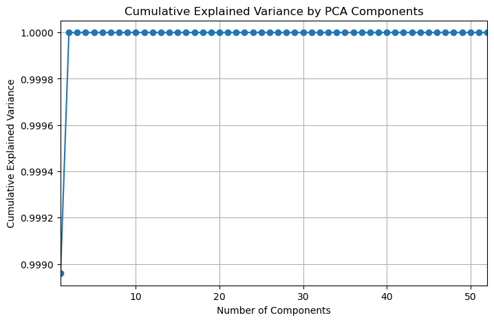

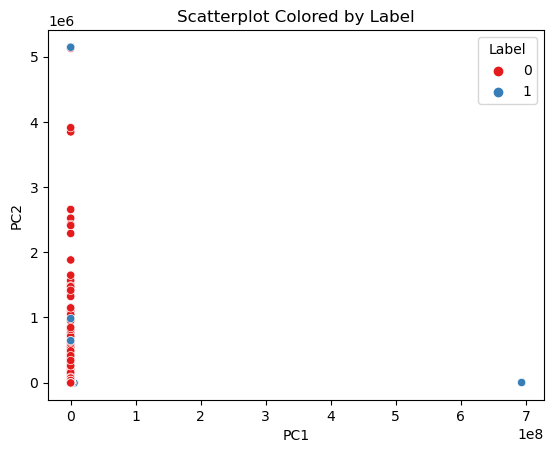

```python
## Plot PCA To understand how many components we need to reppresent the variability of the dataset
plot_pca(df_train_encoded)
```

According to the Cumulative Explained Variance 2 components are sufficient! WOW ... But if we look at the plot with 2 components, we understand that something is wrong.

**We have "forgotten" to normalize!**

```python
#Perform feature normalization and process categorical and numerical features simultaneously

# === 1. Set up column groups ===
ignore_cols = ['label', 'binary_label']  # columns to skip entirely
categorical_cols = ['protocol_type', 'service', 'flag']
numerical_cols = [col for col in df_train.columns if col not in categorical_cols + ignore_cols]

# === 2. Define ColumnTransformer ===
preprocessor = ColumnTransformer(
    transformers=[
        ('num', StandardScaler(), numerical_cols),
        ('cat', OneHotEncoder(handle_unknown='ignore', sparse=False), categorical_cols)
    ],
    remainder='drop'  # drop columns not listed (i.e., ignore_cols)
)

# === 3. Fit on training, transform all splits ===
X_train_transformed = preprocessor.fit_transform(df_train)
X_val_transformed   = preprocessor.transform(df_val)
X_test_transformed  = preprocessor.transform(df_test)

# === 4. Optional: Get transformed feature names and make DataFrames ===
cat_feature_names = preprocessor.named_transformers_['cat'].get_feature_names_out(categorical_cols)
all_feature_names = list(numerical_cols) + list(cat_feature_names)

df_train_preprocessed = pd.DataFrame(X_train_transformed, columns=all_feature_names)
df_val_preprocessed   = pd.DataFrame(X_val_transformed, columns=all_feature_names)
df_test_preprocessed  = pd.DataFrame(X_test_transformed, columns=all_feature_names)



# === 5. Restore the labels ===
df_train_preprocessed["label"] = list(df_train["label"])
df_val_preprocessed["label"]   = list(df_val["label"])
df_test_preprocessed["label"]  = list(df_test["label"])

df_train_preprocessed["binary_label"] = list(df_train["binary_label"])
df_val_preprocessed["binary_label"]   = list(df_val["binary_label"])
df_test_preprocessed["binary_label"]  = list(df_test["binary_label"])
```

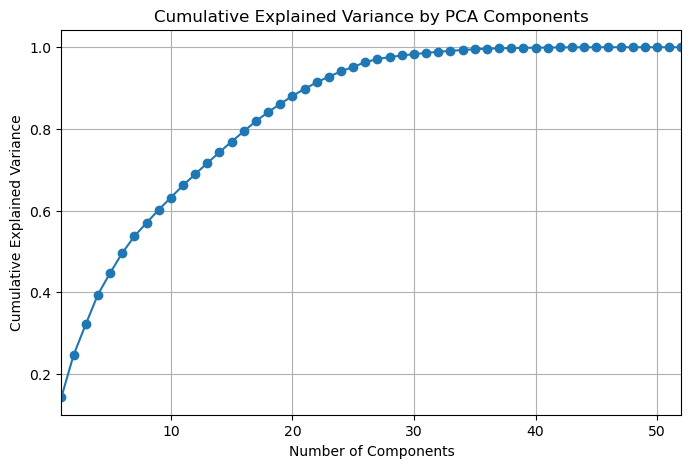

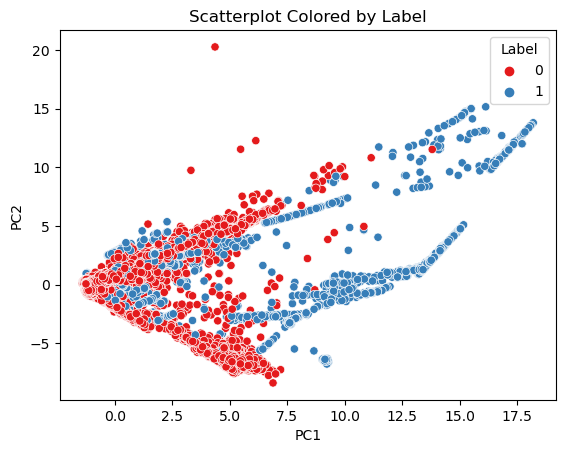

```python
plot_pca(df_train_preprocessed)
```

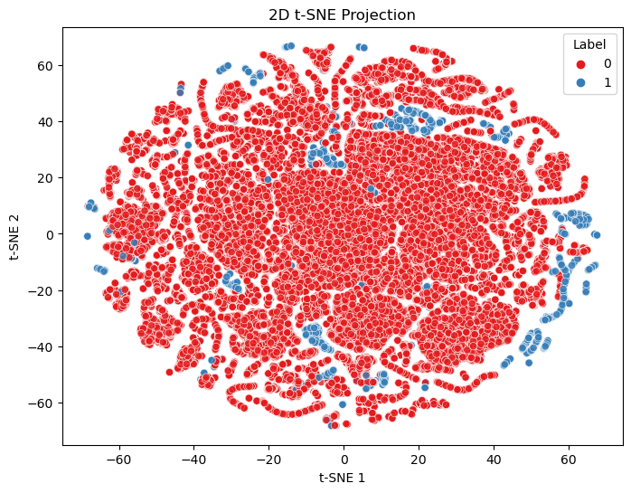

```python
# Use T-SNE for alternative visualization
plot_tsne(df_train_preprocessed)
```

### check the proportion of anomalies w.r.t. normal data

```python
res = df_train_preprocessed.value_counts("binary_label")
anomaly_rate = res[1]/(res[0]+res[1])
print("The fraction of anomalies in the dataset is %.2f"%anomaly_rate)
```

```
The fraction of anomalies in the dataset is 0.06
```

```python
df_train_normal_only = df_train_preprocessed[df_train_preprocessed["binary_label"]==0].copy()
X_train_normal_only = df_train_normal_only.drop(columns=['label', 'binary_label'])
y_train_normal_only = list(df_train_normal_only['binary_label'])

X_train = df_train_preprocessed.drop(columns=['label', 'binary_label'])
y_original_train = list(df_train_preprocessed['label'])
y_train = list(df_train_preprocessed['binary_label'])

X_val = df_val_preprocessed.drop(columns=['label', 'binary_label'])
y_original_val = list(df_val_preprocessed['label'])
y_val = list(df_val_preprocessed['binary_label'])

X_test = df_test_preprocessed.drop(columns=['label', 'binary_label'])
y_original_test = list(df_test_preprocessed['label'])
y_test = list(df_test_preprocessed['binary_label'])
```

# Shallow Anomaly Detection

```python
def plot_confusion_matrix(y_binary, y_pred, methodology, data_name):

    print("\nClassification Report (%s vs Ground Truth):", methodology)
    print(classification_report(y_binary, y_pred))

    # Confusion matrix
    cm = confusion_matrix(y_binary, y_pred)
    sns.heatmap(cm, annot=True, fmt='d', cmap='Blues', xticklabels=['Normal','Anomaly'], yticklabels=['Normal','Anomaly'])
    plt.title('Confusion Matrix %s with %s'%(data_name,methodology))
    plt.xlabel('Predicted')
    plt.ylabel('True')
    plt.show()
    plt.close()
```

### **NOTICE**: In ALL the following code we are not performing any parameter optimization.

For optimizing the parameters of the different algorithms we should use the classic train/validation process

```python
### Anomaly Detection using SVM input data with normal data only - kind of "supervised"
```

```python
# === 1. Fit One-Class SVM ===
# Assume X_train is your input data (numpy array or DataFrame with features only)
ocsvm_normal_only = OneClassSVM(kernel='rbf', gamma='scale', nu=0.001)  # nu = expected anomaly proportion - only normal data
ocsvm_normal_only.fit(X_train_normal_only)
```

```
OneClassSVM(nu=0.001)
```

```python
# === 2. Inference ===
# Predict returns 1 for inliers, -1 for outliers
# Convert to binary anomaly labels: 1 = anomaly, 0 = normal

y_train_pred = ocsvm_normal_only.predict(X_train)
y_train_pred_binary = (y_train_pred == -1).astype(int)


y_val_pred = ocsvm_normal_only.predict(X_val)
y_val_pred_binary = (y_val_pred == -1).astype(int)

y_test_pred = ocsvm_normal_only.predict(X_test)
y_test_pred_binary = (y_test_pred == -1).astype(int)
```

```
Classification Report (%s vs Ground Truth): O-SVM
              precision    recall  f1-score   support

           0       0.98      1.00      0.99     71142
           1       0.94      0.65      0.77      4807

    accuracy                           0.98     75949
   macro avg       0.96      0.82      0.88     75949
weighted avg       0.97      0.98      0.97     75949
```

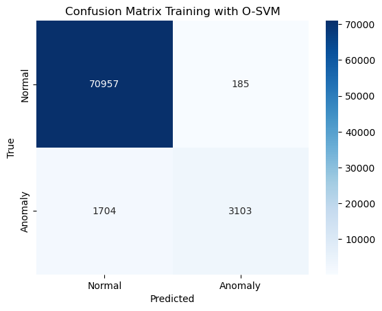

```
Classification Report (%s vs Ground Truth): O-SVM
              precision    recall  f1-score   support

           0       0.97      0.99      0.98      7905
           1       0.89      0.62      0.73       534

    accuracy                           0.97      8439
   macro avg       0.93      0.81      0.86      8439
weighted avg       0.97      0.97      0.97      8439
```

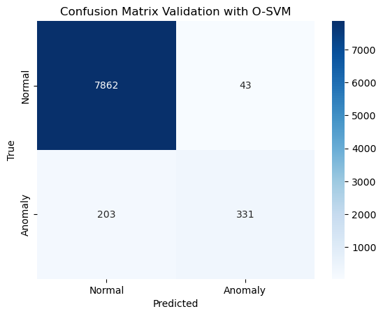

```
Classification Report (%s vs Ground Truth): O-SVM
              precision    recall  f1-score   support

           0       0.98      0.99      0.98      8784
           1       0.88      0.64      0.74       593

    accuracy                           0.97      9377
   macro avg       0.93      0.82      0.86      9377
weighted avg       0.97      0.97      0.97      9377
```

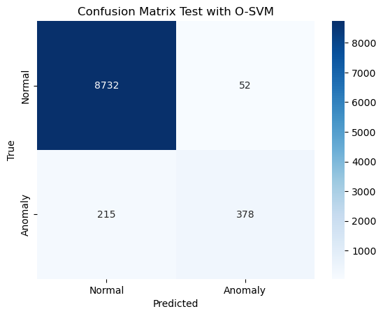

```python
plot_confusion_matrix(y_train, y_train_pred_binary, "O-SVM", "Training")
plot_confusion_matrix(y_val, y_val_pred_binary, "O-SVM", "Validation")
plot_confusion_matrix(y_test, y_test_pred_binary, "O-SVM", "Test")
```

```python
# === 3. Anomaly score (distance from separating hyperplane) ===
anomaly_scores = ocsvm_normal_only.decision_function(X_val)  # the higher, the more normal
# We may use it to investigate the anomalies
```

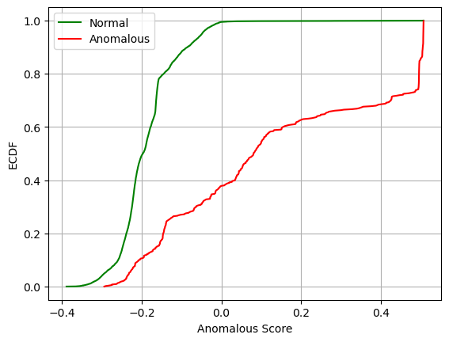

```python
anomalous_points_scores = anomaly_scores[np.array(y_val) == 1]
normal_points_scores = anomaly_scores[np.array(y_val) == 0]
plt.plot(sorted(-normal_points_scores), [i/len(normal_points_scores) for i in range(len(normal_points_scores))], label = "Normal", c="green")
plt.plot(sorted(-anomalous_points_scores),[i/len(anomalous_points_scores) for i in range(len(anomalous_points_scores))], label = "Anomalous", c="red")
plt.legend()
plt.grid()
plt.xlabel("Anomalous Score")
plt.ylabel("ECDF")
plt.show()
```

### Anomaly Detection using SVM input data with both normal and anomalous data

```python
# === 1. Fit One-Class SVM ===
# Assume X_train is your input data (numpy array or DataFrame with features only)
ocsvm = OneClassSVM(kernel='rbf', gamma='scale', nu=0.06)  # nu = estimated anomaly proportion
ocsvm.fit(X_train)
```

```
OneClassSVM(nu=0.06)
```

```python
# === 2. Inference ===
# Predict returns 1 for inliers, -1 for outliers
# Convert to binary anomaly labels: 1 = anomaly, 0 = normal

y_train_pred = ocsvm.predict(X_train)
y_train_pred_binary = (y_train_pred == -1).astype(int)


y_val_pred = ocsvm.predict(X_val)
y_val_pred_binary = (y_val_pred == -1).astype(int)

y_test_pred = ocsvm.predict(X_test)
y_test_pred_binary = (y_test_pred == -1).astype(int)
```

```
Classification Report (%s vs Ground Truth): O-SVM
              precision    recall  f1-score   support

           0       0.96      0.97      0.97     71142
           1       0.48      0.46      0.47      4807

    accuracy                           0.93     75949
   macro avg       0.72      0.71      0.72     75949
weighted avg       0.93      0.93      0.93     75949
```

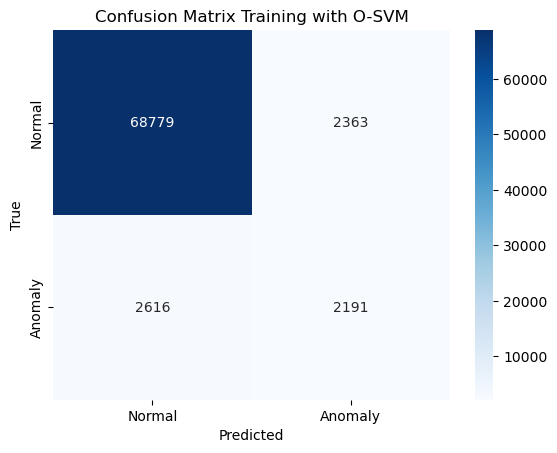

```
Classification Report (%s vs Ground Truth): O-SVM
              precision    recall  f1-score   support

           0       0.96      0.97      0.96      7905
           1       0.47      0.45      0.46       534

    accuracy                           0.93      8439
   macro avg       0.71      0.71      0.71      8439
weighted avg       0.93      0.93      0.93      8439
```

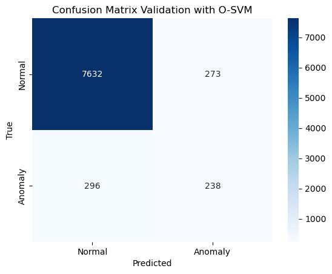

```
Classification Report (%s vs Ground Truth): O-SVM
              precision    recall  f1-score   support

           0       0.96      0.96      0.96      8784
           1       0.47      0.46      0.46       593

    accuracy                           0.93      9377
   macro avg       0.71      0.71      0.71      9377
weighted avg       0.93      0.93      0.93      9377
```

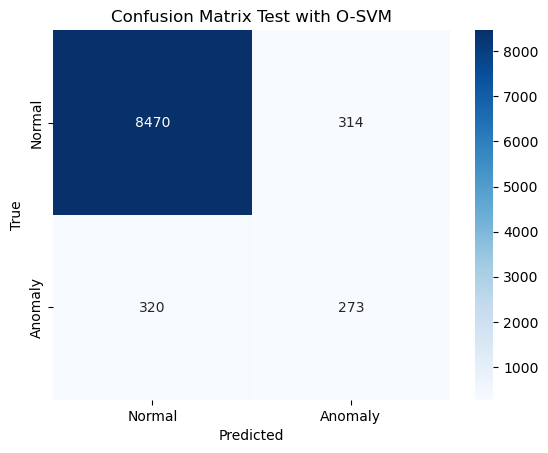

```python
plot_confusion_matrix(y_train, y_train_pred_binary, "O-SVM", "Training")
plot_confusion_matrix(y_val, y_val_pred_binary, "O-SVM", "Validation")
plot_confusion_matrix(y_test, y_test_pred_binary, "O-SVM", "Test")
```

```python
# === 3. Anomaly score (distance from separating hyperplane) ===
anomaly_scores = ocsvm.decision_function(X_val)  # the higher, the more normal
# We may use it to investigate the anomalies
```

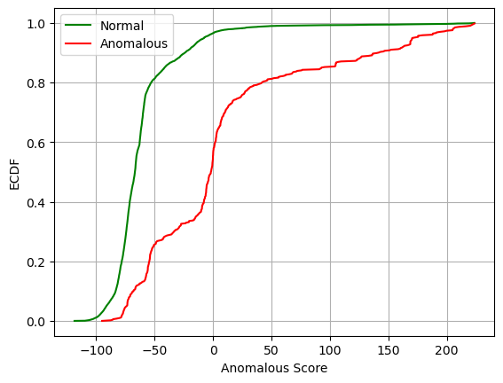

```python
anomalous_points_scores = anomaly_scores[np.array(y_val) == 1]
normal_points_scores = anomaly_scores[np.array(y_val) == 0]
plt.plot(sorted(-normal_points_scores), [i/len(normal_points_scores) for i in range(len(normal_points_scores))], label = "Normal", c="green")
plt.plot(sorted(-anomalous_points_scores),[i/len(anomalous_points_scores) for i in range(len(anomalous_points_scores))], label = "Anomalous", c="red")
plt.legend()
plt.grid()
plt.xlabel("Anomalous Score")
plt.ylabel("ECDF")
plt.show()
```

## Anomaly Detection using LOF

In Sklearn we have a contamination parameter to transform LOF in a classifier as well

**Notice:** the lof_scores is available!

```python
lof = LocalOutlierFactor(n_neighbors=10, contamination=0.06)  # adjust contamination as needed
#LOF does not have a predict if not for novelty prediction - we have to create a single dataset to find all anomalies

X_all = pd.concat([X_train,X_val,X_test])
y_all = y_train+y_val+y_test
y_original_all = y_original_train+y_original_val+y_original_test
```

```python
y_pred = lof.fit_predict(X_all)
```

```python
#Negate because sklearn use negative instead of positive LOF score
lof_scores = -lof.negative_outlier_factor_
```

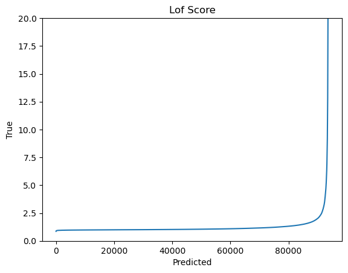

```python
plt.plot(sorted(lof_scores))
plt.title('Lof Score')
plt.xlabel('Predicted')
plt.ylabel('True')
plt.ylim(0,20)
plt.show()
plt.close()
```

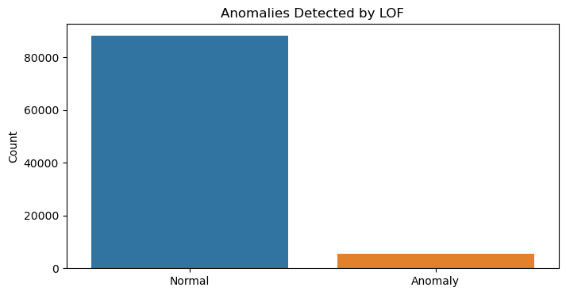

```python
# LOF labels: -1 = anomaly, 1 = normal
y_pred_binary = (y_pred == -1).astype(int)

# 6. Visualize LOF results
plt.figure(figsize=(8, 4))
sns.countplot(x=y_pred_binary)
plt.title('Anomalies Detected by LOF')
plt.xticks([0, 1], ['Normal', 'Anomaly'])
plt.ylabel('Count')
plt.show()
```

```
Classification Report (%s vs Ground Truth): LOF
              precision    recall  f1-score   support

           0       0.94      0.94      0.94     87831
           1       0.06      0.05      0.06      5934

    accuracy                           0.88     93765
   macro avg       0.50      0.50      0.50     93765
weighted avg       0.88      0.88      0.88     93765
```

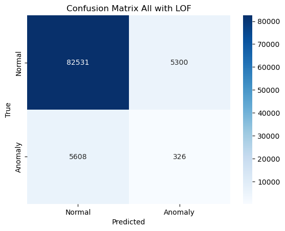

```python
plot_confusion_matrix(y_all, y_pred_binary, "LOF", "All")
```

## Anomaly Detection with Clustering

```python
# Function to compute SSE (Sum of Squared Errors)
def compute_sse(X, centroids, labels):
    """
    Compute the Sum of Squared Errors (SSE) for a given clustering.

    Parameters:
    - X : ndarray of shape (n_samples, n_features)
        The input data.
    - labels : array-like of shape (n_samples,)
        Cluster labels assigned to each point. Should not contain -1.

    Returns:
    - sse : float
        The SSE (sum of squared distances to cluster centroids).
    """
    unique_labels = np.unique(labels)
    sse = 0.0

    for label in unique_labels:
        if label == -1:
            continue  # Skip noise points (e.g., in DBSCAN)
        cluster_points = X[labels == label]
        centroid = centroids[label]#cluster_points.mean(axis=0)
        sse += np.sum((cluster_points.values - centroid) ** 2)

    return sse


def compute_silhouette_details(X, labels):
    # Remove noise points if any (e.g., DBSCAN)
    mask = labels != -1
    X_clean = X[mask]
    labels_clean = labels[mask]

    # Compute overall silhouette score
    silhouette_avg = silhouette_score(X_clean, labels_clean)

    # Compute per-sample silhouette scores
    sample_silhouette_values = silhouette_samples(X_clean, labels_clean)

    # Aggregate by cluster
    cluster_silhouettes = {}
    for cluster in np.unique(labels_clean):
        cluster_silhouettes[cluster] = sample_silhouette_values[labels_clean == cluster].mean()

    return silhouette_avg, cluster_silhouettes, sample_silhouette_values


def plot_silhouette(silhouette_avg,sample_silhouette_values,cluster_labels):

    distinct_labels = set(cluster_labels)
    n_clusters = len(distinct_labels)
    if(-1 in distinct_labels):
        n_clusters -=1

    print("For n_clusters =",n_clusters,"The average silhouette_score is :",silhouette_avg)

    fig, ax = plt.subplots(figsize=(8, 6))

    y_lower = 10

    for i in range(n_clusters):

        # Aggregate the silhouette scores for samples belonging to
        # cluster i, and sort them
        ith_cluster_silhouette_values = sample_silhouette_values[cluster_labels == i]
        print("cluster",i,"size",len(ith_cluster_silhouette_values))
        ith_cluster_silhouette_values.sort()

        size_cluster_i = ith_cluster_silhouette_values.shape[0]
        y_upper = y_lower + size_cluster_i

        color = cm.nipy_spectral(float(i) / n_clusters)
        ax.fill_betweenx(
            np.arange(y_lower, y_upper),
            0,
            ith_cluster_silhouette_values,
            facecolor=color,
            edgecolor=color,
            alpha=0.7,
        )

        # Label the silhouette plots with their cluster numbers at the middle
        ax.text(-0.05, y_lower + 0.5 * size_cluster_i, str(i))

        # Compute the new y_lower for next plot
        y_lower = y_upper + 10  # 10 for the 0 samples



    ax.set_title("The silhouette plot for the various clusters.")
    ax.set_xlabel("The silhouette coefficient values")
    ax.set_ylabel("Cluster label")

    # The vertical line for average silhouette score of all the values
    ax.axvline(x=silhouette_avg, color="red", linestyle="--")

    ax.set_yticks([])  # Clear the yaxis labels / ticks
    ax.set_xticks([-0.1, 0, 0.2, 0.4, 0.6, 0.8, 1])

    plt.show()
    plt.close()
    return
```

```python
# Set number of clusters
SSE_cluster = []
N_Cluster = []
for i in range(2,20):
    kmeans = KMeans(n_clusters=i, random_state=42)
    kmeans_labels = kmeans.fit_predict(X_all)
    kmeans_centers = kmeans.cluster_centers_
    SSE_cluster.append(compute_sse(X_all,kmeans_centers,kmeans_labels))
    N_Cluster.append(i)
```

```python
# Check how many clusters to create based on SSE score
```

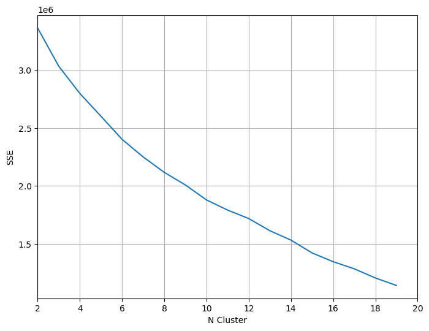

```python
fig, ax = plt.subplots(figsize=(8, 6))

ax.plot(N_Cluster,SSE_cluster)
ax.set_xlabel("N Cluster")
ax.set_ylabel("SSE")
plt.grid()
ax.set_xlim(2,20)
plt.show()
plt.close()
```

```python
# Use the decided number of clusters to create the clustering result
```

```python
# Set number of clusters
kmeans = KMeans(n_clusters=10, random_state=42)
kmeans_labels = kmeans.fit_predict(X_all)
# Get cluster labels
cluster_labels = kmeans.labels_
```

```python
# Check clusters based on silhouettes
```

```
K-Means SSE: 857858203.64
K-Means Silhouette Score: 0.43
For n_clusters = 10 The average silhouette_score is : 0.4252920764302132
cluster 0 size 63232
cluster 1 size 4201
cluster 2 size 5038
cluster 3 size 2
cluster 4 size 782
cluster 5 size 685
cluster 6 size 18648
cluster 7 size 296
cluster 8 size 2
cluster 9 size 879
```

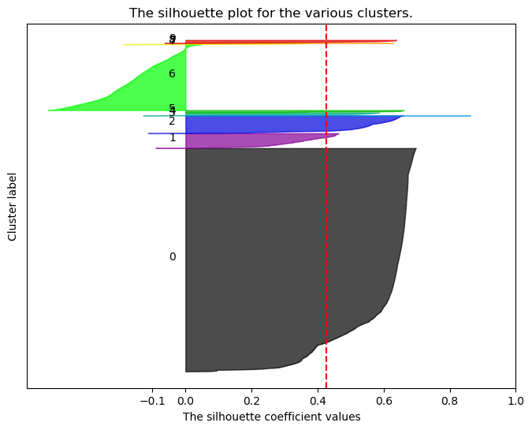

```python
sse_avg = compute_sse(X_all,kmeans_centers,kmeans_labels)
silhouette_avg, clusters_silhouettes, sample_silhouette_values = compute_silhouette_details(X_all, kmeans_labels)

print(f"K-Means SSE: {sse_avg:.2f}")
print(f"K-Means Silhouette Score: {silhouette_avg:.2f}")
plot_silhouette(silhouette_avg,sample_silhouette_values,cluster_labels)
```

**Notice:** We will use only the distance from centroid to find anomalies for every cluster...

- But checking the result.. small clusters may be anomalies.

```python
# Compute distance to assigned cluster center
_, distances_center = pairwise_distances_argmin_min(X_all, kmeans.cluster_centers_)
```

```
Classification Report (%s vs Ground Truth): K-Means
              precision    recall  f1-score   support

           0       0.96      0.97      0.97     87831
           1       0.49      0.47      0.48      5934

    accuracy                           0.94     93765
   macro avg       0.73      0.72      0.72     93765
weighted avg       0.93      0.94      0.93     93765
```

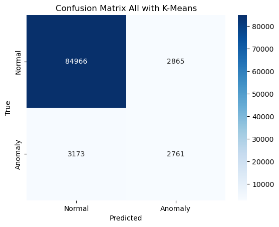

```python
# Set a threshold for anomaly 100 - anomaloues percenties
threshold = np.percentile(distances_center, 100-int(0.06*100))
y_pred_binary_kmeans = y_pred_binary_kmeans = [1 if distance > threshold else 0 for distance in distances_center]

plot_confusion_matrix(y_all, y_pred_binary_kmeans, "K-Means", "All")
```

### Investigate single cluster label

```python
df_clusters = pd.DataFrame({
    "Cluster_label": kmeans_labels,
    "label": y_original_all,
    "binary_label": y_all}
)
```

```python
# Step 1: Group and count
label_counts = df_clusters.groupby('Cluster_label')['label'].value_counts().unstack(fill_value=0)

# Step 2: Reorder columns with 'normal' first
cols = label_counts.columns.tolist()
if 'normal' in cols:
    cols.remove('normal')
    cols = ['normal'] + cols
label_counts = label_counts[cols]

label_counts
```

| label Cluster_label | normal | back | buffer_overflow | ftp_write | guess_passwd | imap | ipsweep | land | loadmodule | multihop | ... | phf | pod | portsweep | rootkit | satan | smurf | spy | teardrop | warezclient | warezmaster |
| --- | --- | --- | --- | --- | --- | --- | --- | --- | --- | --- | --- | --- | --- | --- | --- | --- | --- | --- | --- | --- | --- |
| 0 | 62234 | 896 | 0 | 0 | 0 | 0 | 0 | 0 | 0 | 0 | ... | 3 | 0 | 0 | 0 | 0 | 99 | 0 | 0 | 0 | 0 |
| 1 | 3978 | 0 | 0 | 1 | 0 | 0 | 3 | 0 | 0 | 0 | ... | 0 | 1 | 82 | 0 | 133 | 0 | 0 | 0 | 2 | 0 |
| 2 | 4697 | 11 | 0 | 0 | 50 | 0 | 84 | 0 | 0 | 0 | ... | 0 | 0 | 195 | 0 | 0 | 0 | 0 | 0 | 1 | 0 |
| 3 | 2 | 0 | 0 | 0 | 0 | 0 | 0 | 0 | 0 | 0 | ... | 0 | 0 | 0 | 0 | 0 | 0 | 0 | 0 | 0 | 0 |
| 4 | 9 | 0 | 2 | 0 | 0 | 0 | 0 | 0 | 0 | 0 | ... | 0 | 0 | 110 | 0 | 561 | 0 | 0 | 100 | 0 | 0 |
| 5 | 371 | 0 | 0 | 2 | 1 | 0 | 0 | 0 | 0 | 2 | ... | 0 | 0 | 0 | 0 | 0 | 0 | 0 | 0 | 307 | 2 |
| 6 | 16140 | 61 | 28 | 4 | 0 | 2 | 564 | 0 | 9 | 5 | ... | 1 | 205 | 1 | 10 | 48 | 21 | 2 | 818 | 581 | 18 |
| 7 | 41 | 0 | 0 | 0 | 2 | 10 | 0 | 19 | 0 | 0 | ... | 0 | 0 | 28 | 0 | 164 | 0 | 0 | 0 | 2 | 0 |
| 8 | 1 | 0 | 0 | 1 | 0 | 0 | 0 | 0 | 0 | 0 | ... | 0 | 0 | 0 | 0 | 0 | 0 | 0 | 0 | 0 | 0 |
| 9 | 358 | 0 | 0 | 0 | 0 | 0 | 0 | 0 | 0 | 0 | ... | 0 | 0 | 0 | 0 | 0 | 521 | 0 | 0 | 0 | 0 |

10 rows × 22 columns

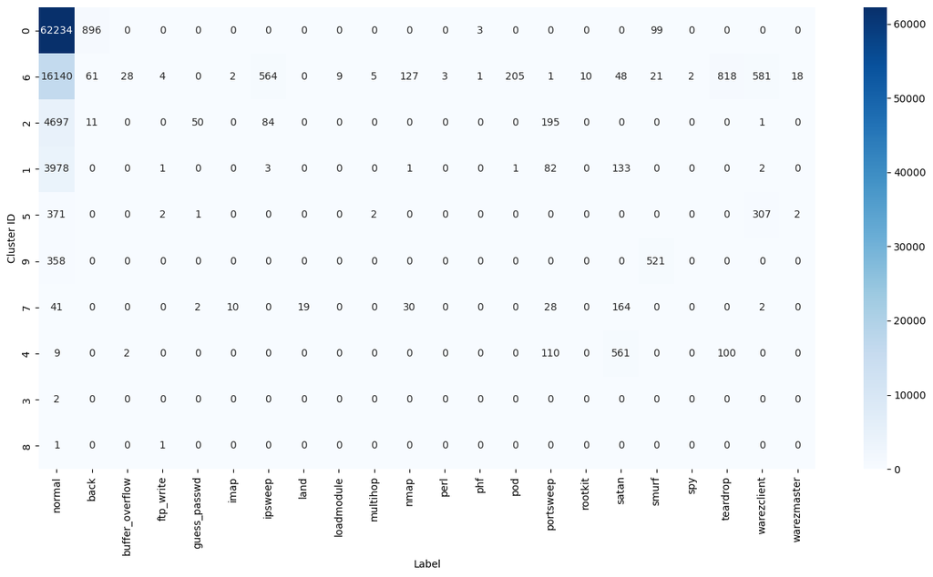

```python
plt.figure(figsize=(14, 8))
sns.heatmap(label_counts.sort_values(by="normal", ascending=False), annot=True, fmt="d", cmap="Blues", cbar=True)
plt.xlabel("Label")
plt.ylabel("Cluster ID")
plt.tight_layout()
plt.show()
plt.close()
```

```python
df_normalized
```

| label Cluster_label | normal | back | buffer_overflow | ftp_write | guess_passwd | imap | ipsweep | land | loadmodule | multihop | ... | phf | pod | portsweep | rootkit | satan | smurf | spy | teardrop | warezclient | warezmaster |
| --- | --- | --- | --- | --- | --- | --- | --- | --- | --- | --- | --- | --- | --- | --- | --- | --- | --- | --- | --- | --- | --- |
| 0 | 0.984217 | 0.014170 | 0.000000 | 0.000000 | 0.000000 | 0.000000 | 0.000000 | 0.000000 | 0.000000 | 0.000000 | ... | 0.000047 | 0.000000 | 0.000000 | 0.000000 | 0.000000 | 0.001566 | 0.000000 | 0.000000 | 0.000000 | 0.000000 |
| 1 | 0.946917 | 0.000000 | 0.000000 | 0.000238 | 0.000000 | 0.000000 | 0.000714 | 0.000000 | 0.000000 | 0.000000 | ... | 0.000000 | 0.000238 | 0.019519 | 0.000000 | 0.031659 | 0.000000 | 0.000000 | 0.000000 | 0.000476 | 0.000000 |
| 2 | 0.932314 | 0.002183 | 0.000000 | 0.000000 | 0.009925 | 0.000000 | 0.016673 | 0.000000 | 0.000000 | 0.000000 | ... | 0.000000 | 0.000000 | 0.038706 | 0.000000 | 0.000000 | 0.000000 | 0.000000 | 0.000000 | 0.000198 | 0.000000 |
| 3 | 1.000000 | 0.000000 | 0.000000 | 0.000000 | 0.000000 | 0.000000 | 0.000000 | 0.000000 | 0.000000 | 0.000000 | ... | 0.000000 | 0.000000 | 0.000000 | 0.000000 | 0.000000 | 0.000000 | 0.000000 | 0.000000 | 0.000000 | 0.000000 |
| 4 | 0.011509 | 0.000000 | 0.002558 | 0.000000 | 0.000000 | 0.000000 | 0.000000 | 0.000000 | 0.000000 | 0.000000 | ... | 0.000000 | 0.000000 | 0.140665 | 0.000000 | 0.717391 | 0.000000 | 0.000000 | 0.127877 | 0.000000 | 0.000000 |
| 5 | 0.541606 | 0.000000 | 0.000000 | 0.002920 | 0.001460 | 0.000000 | 0.000000 | 0.000000 | 0.000000 | 0.002920 | ... | 0.000000 | 0.000000 | 0.000000 | 0.000000 | 0.000000 | 0.000000 | 0.000000 | 0.000000 | 0.448175 | 0.002920 |
| 6 | 0.865508 | 0.003271 | 0.001502 | 0.000215 | 0.000000 | 0.000107 | 0.030245 | 0.000000 | 0.000483 | 0.000268 | ... | 0.000054 | 0.010993 | 0.000054 | 0.000536 | 0.002574 | 0.001126 | 0.000107 | 0.043865 | 0.031156 | 0.000965 |
| 7 | 0.138514 | 0.000000 | 0.000000 | 0.000000 | 0.006757 | 0.033784 | 0.000000 | 0.064189 | 0.000000 | 0.000000 | ... | 0.000000 | 0.000000 | 0.094595 | 0.000000 | 0.554054 | 0.000000 | 0.000000 | 0.000000 | 0.006757 | 0.000000 |
| 8 | 0.500000 | 0.000000 | 0.000000 | 0.500000 | 0.000000 | 0.000000 | 0.000000 | 0.000000 | 0.000000 | 0.000000 | ... | 0.000000 | 0.000000 | 0.000000 | 0.000000 | 0.000000 | 0.000000 | 0.000000 | 0.000000 | 0.000000 | 0.000000 |
| 9 | 0.407281 | 0.000000 | 0.000000 | 0.000000 | 0.000000 | 0.000000 | 0.000000 | 0.000000 | 0.000000 | 0.000000 | ... | 0.000000 | 0.000000 | 0.000000 | 0.000000 | 0.000000 | 0.592719 | 0.000000 | 0.000000 | 0.000000 | 0.000000 |

10 rows × 22 columns

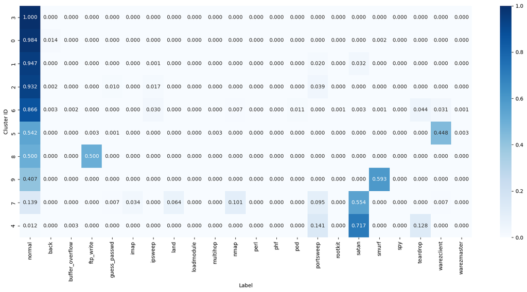

```python
df_normalized = label_counts.div(label_counts.sum(axis=1), axis=0)
plt.figure(figsize=(16, 8))
sns.heatmap(df_normalized.sort_values(by="normal", ascending=False), annot=True, fmt=".3f", cmap="Blues", cbar=True)
plt.xlabel("Label")
plt.ylabel("Cluster ID")
plt.tight_layout()
plt.show()
plt.close()
```

This heatmap shows, with a confusion matrix, how the original labels are distributed across the cluster.

**Takeaway**: Most of the normal behavior is represented by cluster 0. Other clusters, such as cluster 4, show a large number of anomalies w.r.t. to normal behavior. We could examine the points of this cluster to understand how they differ from the points of another cluster. e.g., cluster 0. This would help us to understand why this cluster consists mainly of anomalies, e.g. which features have the largest distance to the centroid, or to the two closest points in the clusters, etc.

Additionally, we could plot the t-SNE with the points of these two clusters, using the cluster ID as the label for each point, to see if the t-SNE allows us to visualize some differences.

## DB-Scan

**Check how to tune $\epsilon$ based on the k-nearest neighbor distance**

```python
# X is your dataset (numpy array or DataFrame)
# shape: (n_samples, n_features)
nn = NearestNeighbors(n_neighbors=5, algorithm='auto', n_jobs=-1)
nn.fit(X_all)

# Compute distances to 5 nearest neighbors (including the point itself)
distances, indices = nn.kneighbors(X_all)
```

```python
# Distance to the 4th nearest neighbor (not counting self, which is at index 0)
fourth_neighbor_distances = distances[:, 4]  # 5th closest = 4th real neighbor
# Now fourth_neighbor_distances[i] gives you the distance of point i to its 4th neighbor
```

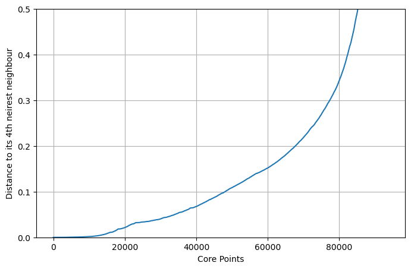

```python
# Plot explained variance ratio
plt.figure(figsize=(8, 5))
plt.plot(sorted( fourth_neighbor_distances))
plt.xlabel('Core Points')
plt.ylabel('Distance to its 4th neirest neighbour')
plt.ylim(0,0.5)
plt.grid(True)
plt.show()
plt.close()
```

```python
# Use DBSCAN with the epsilon and min_points previosly defined
dbscan = DBSCAN(eps=0.15, min_samples=4)
dbscan_labels = dbscan.fit_predict(X_all)
```

```
Classification Report (DBScan vs Ground Truth):
              precision    recall  f1-score   support

           0       0.95      0.71      0.81     87831
           1       0.09      0.40      0.14      5934

    accuracy                           0.69     93765
   macro avg       0.52      0.56      0.48     93765
weighted avg       0.89      0.69      0.77     93765
```

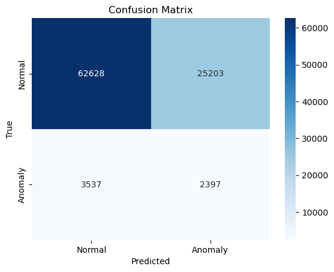

```python
y_pred_binary_dbscan = [1 if label == -1 else 0 for label in dbscan_labels]

print("\nClassification Report (DBScan vs Ground Truth):")
print(classification_report(y_all, y_pred_binary_dbscan))
# Confusion matrix
cm = confusion_matrix(y_all, y_pred_binary_dbscan)
sns.heatmap(cm, annot=True, fmt='d', cmap='Blues', xticklabels=['Normal','Anomaly'], yticklabels=['Normal','Anomaly'])
plt.title('Confusion Matrix')
plt.xlabel('Predicted')
plt.ylabel('True')
plt.show()
```

## Takeaway:

- LOF, K-Means and DB-Scan being distance based may suffer of the course of dimensionality.. We have 50+ feautures

# Deep Learning

```python
from torch.utils.data import TensorDataset, DataLoader
import torch.nn.functional as F
import torch.optim as optim
import torch.nn as nn
import torch
```

## 🧠 1. Define Autoencoder Model

```python
class Autoencoder(nn.Module):
    def __init__(self, input_dim, bottleneck_dim=8):
        super(Autoencoder, self).__init__()

        # Encoder: compress the input
        self.encoder = nn.Sequential(
            nn.Linear(input_dim, 64),
            nn.ReLU(),
            nn.Linear(64, bottleneck_dim)
        )

        # Decoder: reconstruct the input
        self.decoder = nn.Sequential(
            nn.Linear(bottleneck_dim, 64),
            nn.ReLU(),
            nn.Linear(64, input_dim)
        )

    def forward(self, x):
        z = self.encoder(x)       # bottleneck representation
        x_hat = self.decoder(z)   # reconstruction
        return x_hat

    def encode(self, x):
        return self.encoder(x)    # return bottleneck representation
```

```python
class ImprovedAutoencoder(nn.Module):
    def __init__(self, input_dim, bottleneck_dim=16):
        super(ImprovedAutoencoder, self).__init__()

        # Encoder: deeper network, batchnorm, dropout
        self.encoder = nn.Sequential(
            nn.Linear(input_dim, 128),
            nn.BatchNorm1d(128),
            nn.ReLU(),
            nn.Dropout(0.2),

            nn.Linear(128, 64),
            nn.BatchNorm1d(64),
            nn.ReLU(),
            nn.Dropout(0.2),

            nn.Linear(64, bottleneck_dim)
        )

        # Decoder: symmetric structure
        self.decoder = nn.Sequential(
            nn.Linear(bottleneck_dim, 64),
            nn.BatchNorm1d(64),
            nn.ReLU(),
            nn.Dropout(0.2),

            nn.Linear(64, 128),
            nn.BatchNorm1d(128),
            nn.ReLU(),
            nn.Dropout(0.2),

            nn.Linear(128, input_dim)
        )

    def forward(self, x):
        z = self.encoder(x)     # bottleneck representation
        x_hat = self.decoder(z) # reconstruction
        return x_hat

    def encode(self, x):
        return self.encoder(x)  # return bottleneck representation
```

```python
# === 2. Prepare the data ===
```

```python
# Convert to PyTorch tensors
X_tensor = torch.tensor(X_train.values, dtype=torch.float32)

# Create dataset and dataloader
dataset = TensorDataset(X_tensor)
dataloader = DataLoader(dataset, batch_size=64, shuffle=True)
```

## ⚙️ 3. Train the Autoencoder

```python
def mixed_autoencoder_loss(x, x_recon, categorical_dims, numerical_idx):
    """
    Args:
        x: original input [batch_size, num_features]
        x_recon: reconstructed input [batch_size, num_features]
        categorical_dims: list of (start_idx, end_idx) tuples for one-hot encoded categorical features
        numerical_idx: list of indices for numerical features

    Returns:
        Scalar loss value (MSE + sum of CE)
    """
    # Numerical loss (MSE)
    x_num = x[:, numerical_idx]
    x_recon_num = x_recon[:, numerical_idx]
    mse = F.mse_loss(x_recon_num, x_num)

    # Categorical loss (CE for each one-hot feature)
    ce = 0
    for start, end in categorical_dims:
        x_cat = x[:, start:end]
        x_recon_cat = x_recon[:, start:end]

        # CE expects class indices as targets
        target = torch.argmax(x_cat, dim=1)
        ce += F.cross_entropy(x_recon_cat, target)

    return mse + ce


def compute_per_sample_reconstruction_error(x, x_recon, categorical_dims, numerical_idx):
    """
    Returns a vector [batch_size] with the total reconstruction error (MSE + sum CE) for each sample
    """
    batch_size = x.shape[0]

    # Numerical error per sample
    x_num = x[:, numerical_idx]
    x_recon_num = x_recon[:, numerical_idx]
    mse_per_sample = torch.mean((x_num - x_recon_num) ** 2, dim=1)

    # Categorical CE error per sample (sum across categorical features)
    ce_total = torch.zeros(batch_size, device=x.device)
    for start, end in categorical_dims:
        x_cat = x[:, start:end]
        x_recon_cat = x_recon[:, start:end]

        target = torch.argmax(x_cat, dim=1)
        ce = F.cross_entropy(x_recon_cat, target, reduction='none')  # shape: [batch_size]
        ce_total += ce

    # Total reconstruction error per sample
    return mse_per_sample + ce_total
```

```python
#Indexes to compute the loss function based on MSE and CE for categorical features
# Step 1: Get all column names
all_columns = [col for col in df_train_preprocessed.columns if col not in ['label', 'binary_label']]


# Step 2: Get categorical index ranges
categorical_cols = ['protocol_type', 'service', 'flag']
categorical_dims = []
for col in categorical_cols:
    # Get all one-hot columns for this categorical feature
    one_hot_cols = [c for c in all_columns if c.startswith(col + "_")]
    if one_hot_cols:
        start_idx = all_columns.index(one_hot_cols[0])
        end_idx = start_idx + len(one_hot_cols)
        categorical_dims.append((start_idx, end_idx))

# Step 3: Get numerical column indexes
numerical_idx = [i for i, col in enumerate(all_columns)
                 if not any(col.startswith(c + "_") for c in categorical_cols)]
```

```python
# Initialize model
input_dim = X_train.shape[1]
model = Autoencoder(input_dim=input_dim, bottleneck_dim=8)

#Optimizer
optimizer = optim.Adam(model.parameters(), lr=1e-3)
#For the loss we use a custom implemenatation having categorical and numerical features
#mixed_autoencoder_loss


# Training loop
n_epochs = 50
model.train()
train_losses = []
for epoch in range(n_epochs):
    train_loss = 0
    for batch in dataloader:
        x_batch = batch[0]
        optimizer.zero_grad()
        x_hat = model(x_batch)
        loss = mixed_autoencoder_loss(x_batch, x_hat, categorical_dims, numerical_idx)

        loss.backward()
        optimizer.step()
        train_loss += loss.item()
    train_loss /= len(X_tensor)
    train_losses.append(train_loss)  # Store training loss

    print(f"Epoch {epoch+1}/{n_epochs}, Loss: {train_loss:.4f}")
```

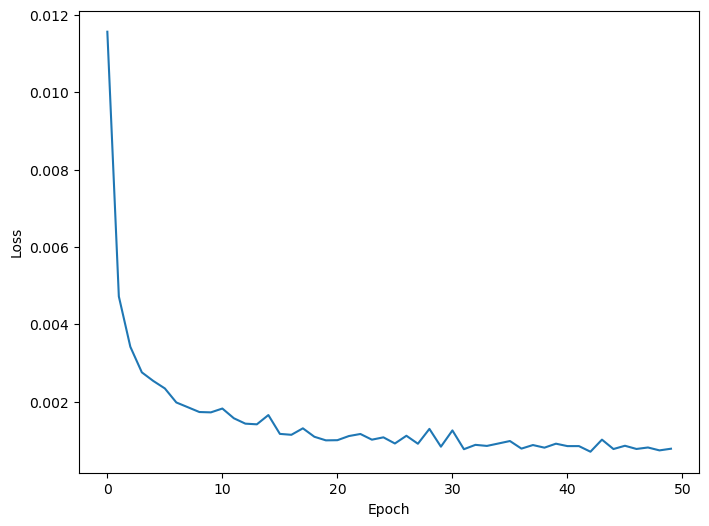

```python
plt.figure(figsize=(8, 6))
plt.plot(train_losses)
plt.xlabel('Epoch')
plt.ylabel('Loss')
plt.show()
plt.close()
```

### 📊 4. Anomaly Scores from Reconstruction Error

```python
# Switch to evaluation mode
model.eval()

# Reconstruct the full dataset
with torch.no_grad():
    X_tensor = X_tensor.to(next(model.parameters()).device)  # ensure correct device
    X_reconstructed = model(X_tensor)

    reconstruction_error = compute_per_sample_reconstruction_error(
        X_tensor, X_reconstructed,
        categorical_dims=categorical_dims,
        numerical_idx=numerical_idx)

# Convert to NumPy
reconstruction_error = reconstruction_error.cpu().numpy()

# Use a threshold or percentile to detect anomalies
threshold = np.percentile(reconstruction_error, 100-int(0.06*100))
predicted_anomalies = (reconstruction_error > threshold).astype(int)
```

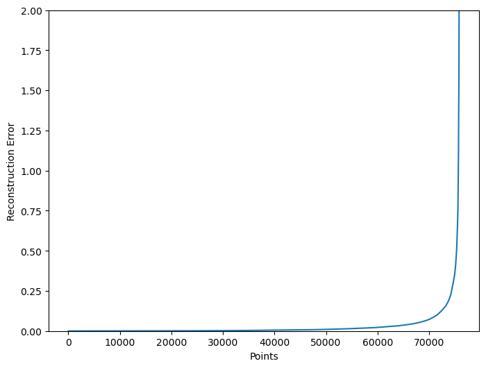

```python
plt.figure(figsize=(8, 6))
plt.plot(sorted(reconstruction_error))
plt.xlabel('Points')
plt.ylabel('Reconstruction Error')
plt.ylim(0,2)
plt.show()
plt.close()
```

```python
### Result very small reconstruction error - probably we need a better model
```

```
Classification Report (Autoencoder vs Ground Truth):
              precision    recall  f1-score   support

           0       0.96      0.96      0.96     71142
           1       0.39      0.37      0.38      4807

    accuracy                           0.92     75949
   macro avg       0.68      0.67      0.67     75949
weighted avg       0.92      0.92      0.92     75949
```

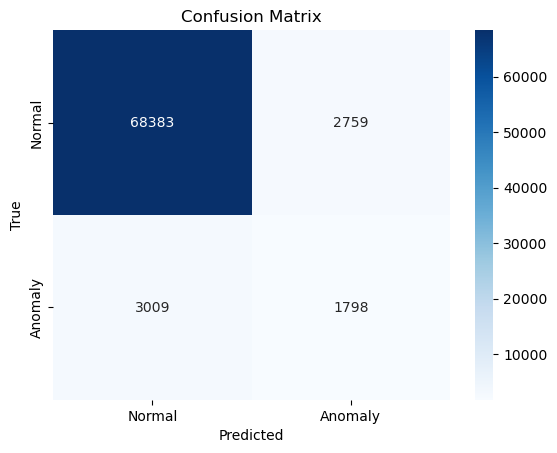

```python
print("\nClassification Report (Autoencoder vs Ground Truth):")
print(classification_report(y_train, predicted_anomalies))
# Confusion matrix
cm = confusion_matrix(y_train, predicted_anomalies)
sns.heatmap(cm, annot=True, fmt='d', cmap='Blues', xticklabels=['Normal','Anomaly'], yticklabels=['Normal','Anomaly'])
plt.title('Confusion Matrix')
plt.xlabel('Predicted')
plt.ylabel('True')
plt.show()
plt.close()
```

### To obtain the bottleneck data representation, we can use the encoder only to encode the input data in latent space.

Then we can use this representation with different shallow models..

```python
with torch.no_grad():
    bottleneck = model.encode(X_tensor).cpu().numpy()
```

```python
bottleneck.shape
```

```
(75949, 8)
```

```python
df_bottlececk = pd.DataFrame(bottleneck)
df_bottlececk['label'] = df_train_preprocessed['label']
df_bottlececk['binary_label'] = df_train_preprocessed['binary_label']
```

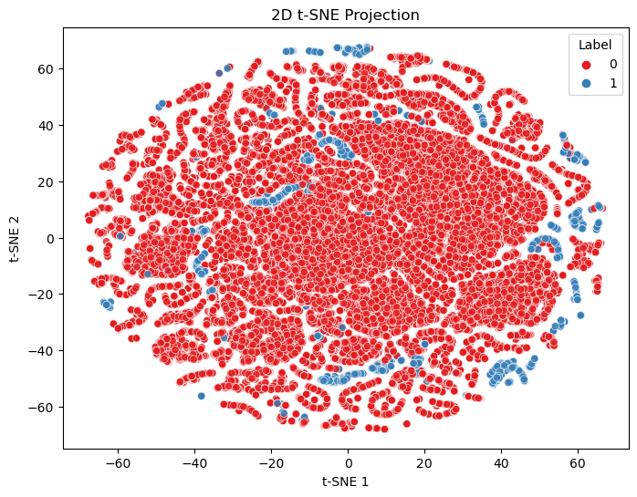

```python
plot_tsne(df_bottlececk)
```

```python
# Initialize a more complex model
input_dim = X_train.shape[1]
model = ImprovedAutoencoder(input_dim=input_dim, bottleneck_dim=8)

# Loss and optimizer
optimizer = optim.Adam(model.parameters(), lr=1e-3)

# Training loop
n_epochs = 50
model.train()
train_losses = []
for epoch in range(n_epochs):
    train_loss = 0
    for batch in dataloader:
        x_batch = batch[0]
        optimizer.zero_grad()
        x_hat = model(x_batch)
        loss = mixed_autoencoder_loss(x_batch, x_hat, categorical_dims, numerical_idx)
        loss.backward()
        optimizer.step()
        train_loss += loss.item()
    train_loss /= len(X_tensor)
    train_losses.append(train_loss)  # Store training loss

    print(f"Epoch {epoch+1}/{n_epochs}, Loss: {train_loss:.4f}")
```

```python
# Switch to evaluation mode
model.eval()

# Reconstruct the full dataset
with torch.no_grad():
    X_tensor = X_tensor.to(next(model.parameters()).device)  # ensure correct device
    X_reconstructed = model(X_tensor)
    reconstruction_error = compute_per_sample_reconstruction_error(
        X_tensor, X_reconstructed,
        categorical_dims=categorical_dims,
        numerical_idx=numerical_idx)

# Convert to NumPy
reconstruction_error = reconstruction_error.cpu().numpy()

# Use a threshold or percentile to detect anomalies
threshold = np.percentile(reconstruction_error, 100-int(0.06*100))
predicted_anomalies = (reconstruction_error > threshold).astype(int)
```

```python
print("\nClassification Report (Autoencoder vs Ground Truth):")
print(classification_report(y_train, predicted_anomalies))
# Confusion matrix
cm = confusion_matrix(y_train, predicted_anomalies)
sns.heatmap(cm, annot=True, fmt='d', cmap='Blues', xticklabels=['Normal','Anomaly'], yticklabels=['Normal','Anomaly'])
plt.title('Confusion Matrix')
plt.xlabel('Predicted')
plt.ylabel('True')
plt.show()
plt.close()
```

[output not shown]

#### Takaway: We have to try much harder to achieve good results.

```python
with torch.no_grad():
    bottleneck = model.encode(X_tensor).cpu().numpy()
```

```python
df_bottlececk = pd.DataFrame(bottleneck)
df_bottlececk['label'] = df_train_preprocessed['label']
df_bottlececk['binary_label'] = df_train_preprocessed['binary_label']
```

```python
plot_tsne(df_bottlececk)
```

[output not shown]